# Spatial Autocorrelation Module

### For our clumped data

```r
#Moran's
moran.out.clump <- moran.test(clumped.df$V3, nb2listw(nb.clump, style = "B"))
moran.out.clump
```

```
##
##  Moran I test under randomisation
##
## data:  clumped.df$V3
## weights: nb2listw(nb.clump, style = "B")
##
## Moran I statistic standard deviate = 29.663, p-value < 2.2e-16
## alternative hypothesis: greater
## sample estimates:
## Moran I statistic       Expectation          Variance
##       0.956020942      -0.002004008       0.001043101
```

```r
moran.clump.mc<- moran.mc(clumped.df$V3, nb2listw(nb.clump, style = "B"), nsim=99)
moran.clump.mc
```

```
##
##  Monte-Carlo simulation of Moran I
##
## data:  clumped.df$V3
## weights: nb2listw(nb.clump, style = "B")
## number of simulations + 1: 100
##
## statistic = 0.95602, observed rank = 100, p-value = 0.01
## alternative hypothesis: greater
```

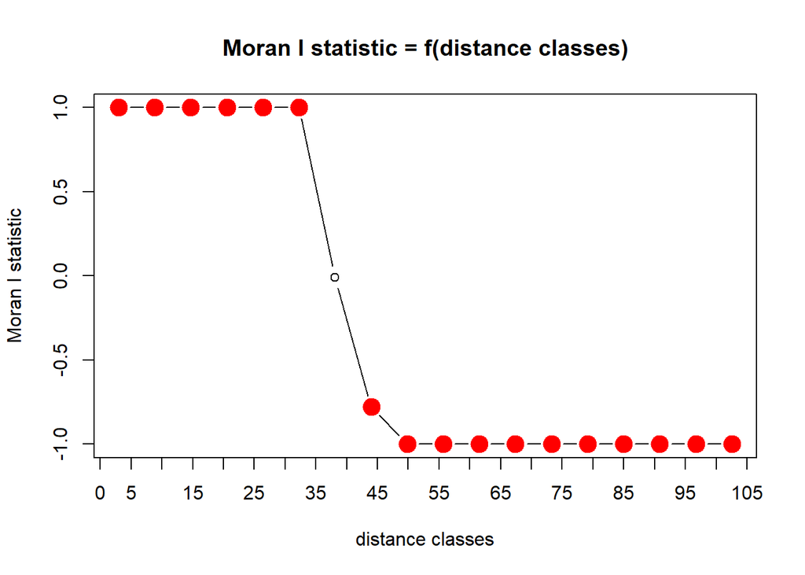

```r
clumped.moran <- correlog(coordinates(clumped.spdf), e$X.1, method = "Moran", nbclass = NULL, alternative = "two.sided")
# Can view the textual results by simply typing 'random.moran'
plot(clumped.moran) #plots the results
```

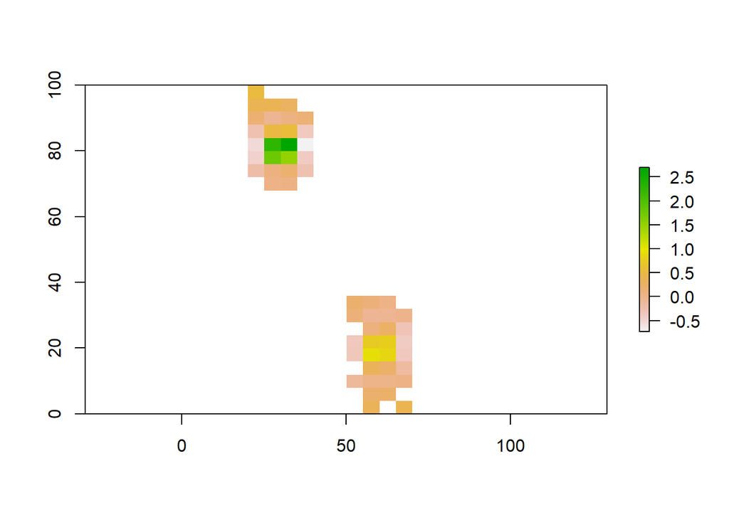

```r
#Local Moran's
clumped.rast.count <-rasterize(clumped.spdf, r, fun=function(x,...)length(x))[[1]]
plot(MoranLocal(clumped.rast.count))
```

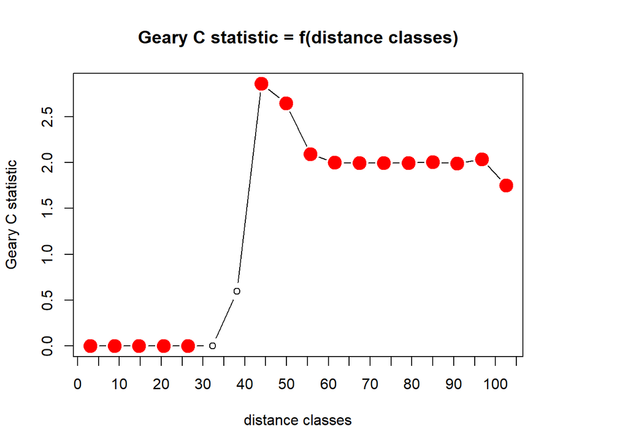

```r
#Geary's C
clumped.geary <- correlog(coordinates(clumped.spdf), e$X.1, method = "Geary", alternative = "two.sided")
plot(clumped.geary)
```

```r
clump.geary.out<- geary.test(clumped.df$V3, nb2listw(nb.clump, style = "B"))
clump.geary.out
```

```
##
##  Geary C test under randomisation
##
## data:  clumped.df$V3
## weights: nb2listw(nb.clump, style = "B")
##
## Geary C statistic standard deviate = 29.663, p-value < 2.2e-16
## alternative hypothesis: Expectation greater than statistic
## sample estimates:
## Geary C statistic       Expectation          Variance
##       0.043891099       1.000000000       0.001038933
```

```r
clump.geary.mc<- geary.mc(clumped.df$V3, nb2listw(nb.clump, style = "B"), nsim=99)
clump.geary.mc
```

```
##
##  Monte-Carlo simulation of Geary C
##
## data:  clumped.df$V3
## weights: nb2listw(nb.clump, style = "B")
## number of simulations + 1: 100
##
## statistic = 0.043891, observed rank = 1, p-value = 0.01
## alternative hypothesis: greater
```

### For our very clumped data

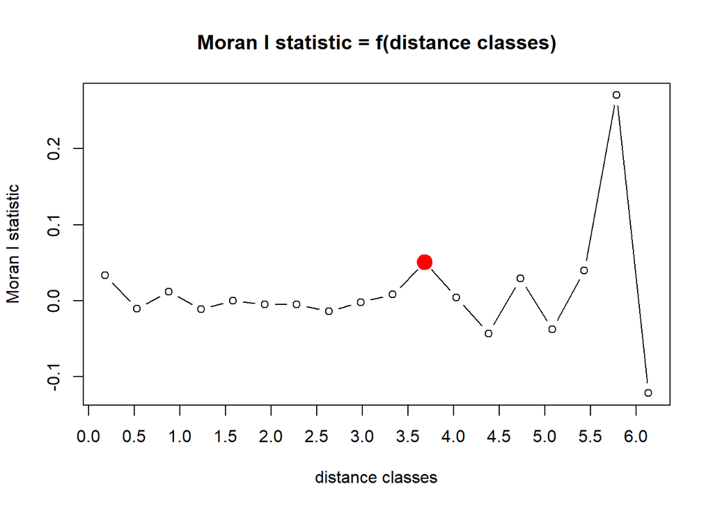

```r
#Moran's I
v_clumped.moran <- correlog(v_clumped.spdf, n$att, method = "Moran", nbclass = NULL, alternative = "two.sided")
# Can view the textual results by simply typing 'random.moran'
plot(v_clumped.moran) #plots the results
```

```r
moran.out.vc <- moran.test(v_clump.df$V3, nb2listw(nb.vc, style = "B"))
moran.out.vc
```

```
##
##  Moran I test under randomisation
##
## data:  v_clump.df$V3
## weights: nb2listw(nb.vc, style = "B")
##
## Moran I statistic standard deviate = 16.272, p-value < 2.2e-16
## alternative hypothesis: greater
## sample estimates:
## Moran I statistic       Expectation          Variance
##       0.523507325      -0.002004008       0.001043016
```

```r
moran.vc.mc<- moran.mc(v_clump.df$V3, nb2listw(nb.vc, style = "B"), nsim=99)
moran.vc.mc
```

```
##
##  Monte-Carlo simulation of Moran I
##
## data:  v_clump.df$V3
## weights: nb2listw(nb.vc, style = "B")
## number of simulations + 1: 100
##
## statistic = 0.52351, observed rank = 100, p-value = 0.01
## alternative hypothesis: greater
```

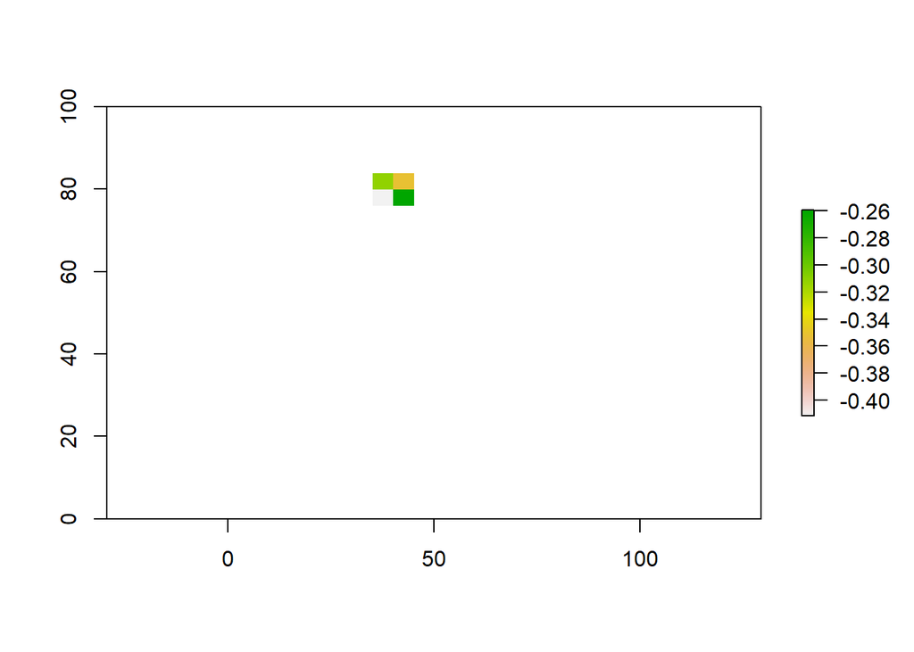

```r
#Local Moran's
vc.rast.count <-rasterize(v_clumped.spdf, r, fun=function(x,...)length(x))[[1]]
plot(MoranLocal(vc.rast.count))
```

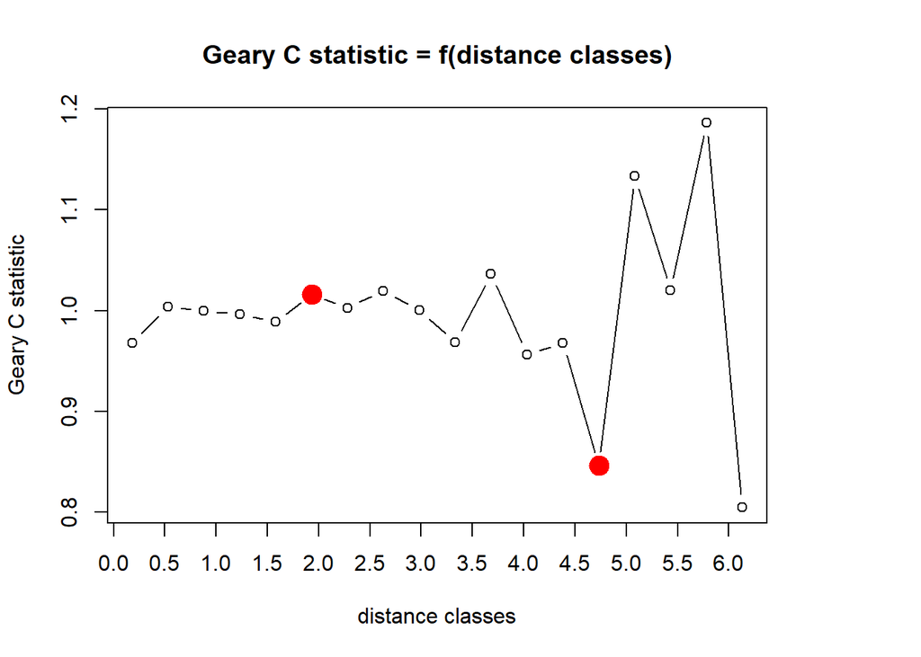

```r
#Geary's C
v_clumped.geary <- correlog(coordinates(v_clumped.spdf), d$att, method = "Geary", alternative = "two.sided")
plot(v_clumped.geary)
```

```r
geary.out.vc<- geary.test(v_clump.df$V3, nb2listw(nb.vc, style = "B"))
geary.out.vc
```

```
##
##  Geary C test under randomisation
##
## data:  v_clump.df$V3
## weights: nb2listw(nb.vc, style = "B")
##
## Geary C statistic standard deviate = 16.281, p-value < 2.2e-16
## alternative hypothesis: Expectation greater than statistic
## sample estimates:
## Geary C statistic       Expectation          Variance
##        0.47501190        1.00000000        0.00103976
```

```r
vc.geary.mc<- geary.mc(v_clump.df$V3, nb2listw(nb.vc, style = "B"), nsim=99)
vc.geary.mc
```

```
##
##  Monte-Carlo simulation of Geary C
##
## data:  v_clump.df$V3
## weights: nb2listw(nb.vc, style = "B")
## number of simulations + 1: 100
##
## statistic = 0.47501, observed rank = 1, p-value = 0.01
## alternative hypothesis: greater
```

# Interpolation

You can also use the data that is already collected to interpolate across to areas for which you have no data. We will use the example from the tree data, though it is admittedly a strange example, as trees dont cover entire areas. The 2 plots have different levels of effect across points, making smoother, or less smooth images.

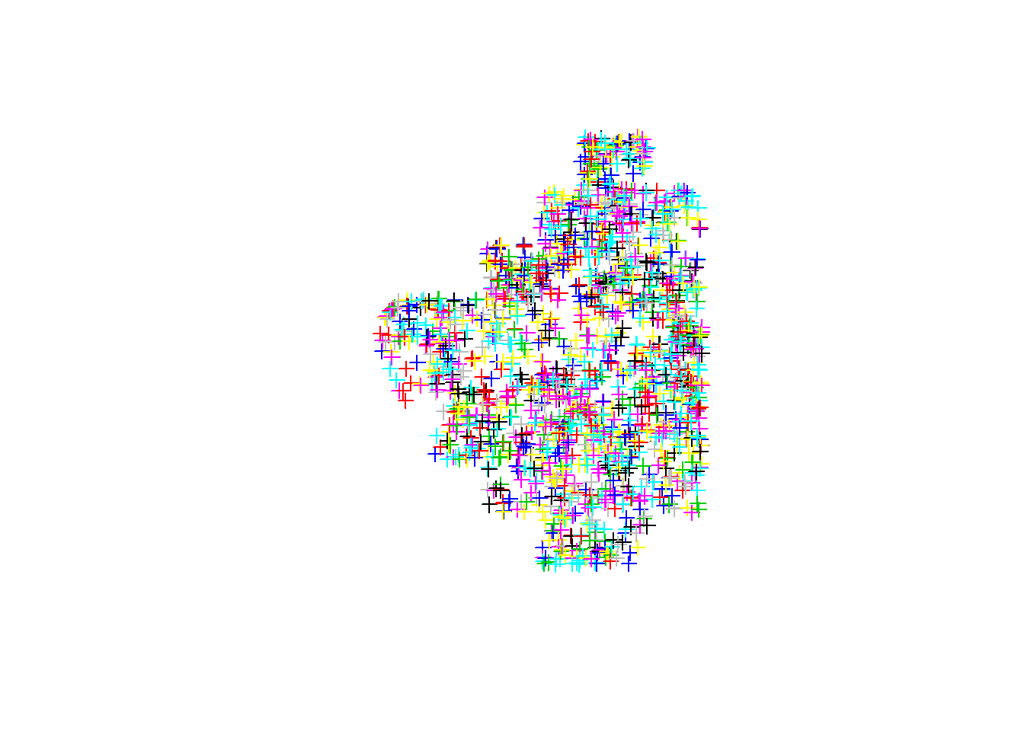

```r
#first the data we have-this is our original raster for the acru trees
plot(acru.spdf, col=acru.spdf$dbh91)
```

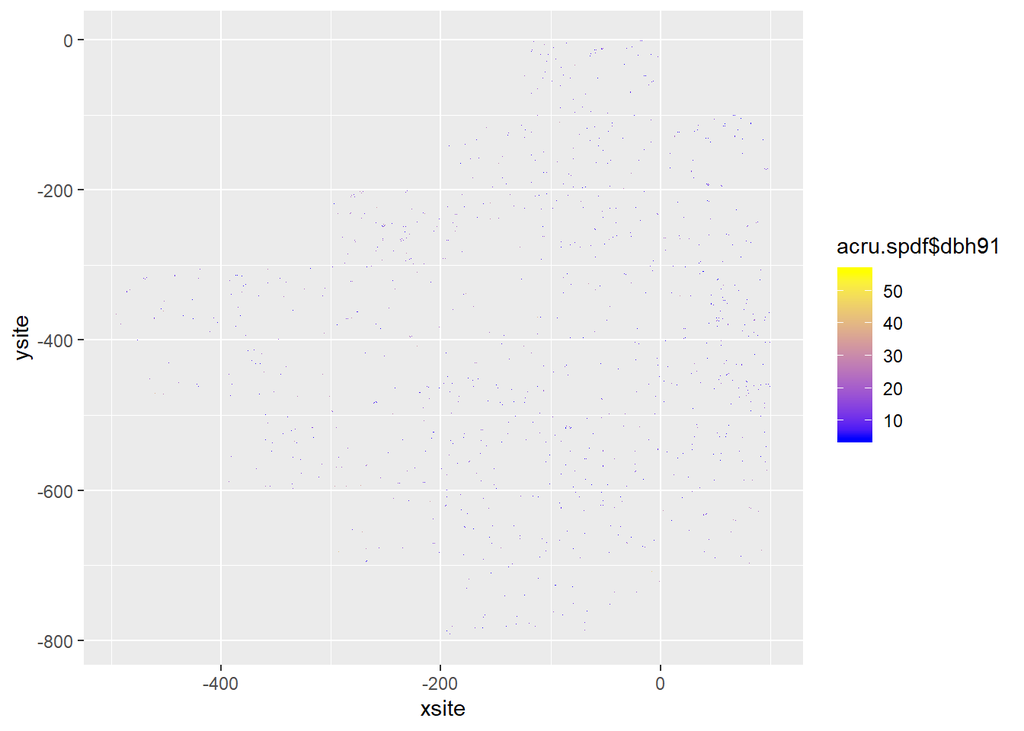

```r
g<- ggplot(data=acru, aes(x=xsite, y=ysite)) + geom_tile(mapping= aes(fill=acru.spdf$dbh91)) + scale_fill_gradient(low="blue", high="yellow")
g
```

Now that we have seen/remembered what our raster looks like, we will interpolate our data to the surrounding areas. This will use the data we have and use distance weighting in the background to casue closer points to have more effect on an interpolated point than farther points.

```r
#Then we will interpolate over the whole area
#First we make a new grid to put the data in
grid.new<-as.data.frame(spsample(acru.spdf ,"regular", n=500))
names(grid.new)       <- c("X", "Y")
coordinates(grid.new) <- c("X", "Y")
gridded(grid.new)     <- TRUE  # Create SpatialPixel object
fullgrid(grid.new)    <- TRUE
#This is the actual interpolation, tell it what to interpolate
#This first one has the least smoothing
P.orig.idw <- gstat::idw(dbh91 ~ 1, acru.spdf, newdata=grid.new, idp=3.0)
```

```
## [inverse distance weighted interpolation]
```

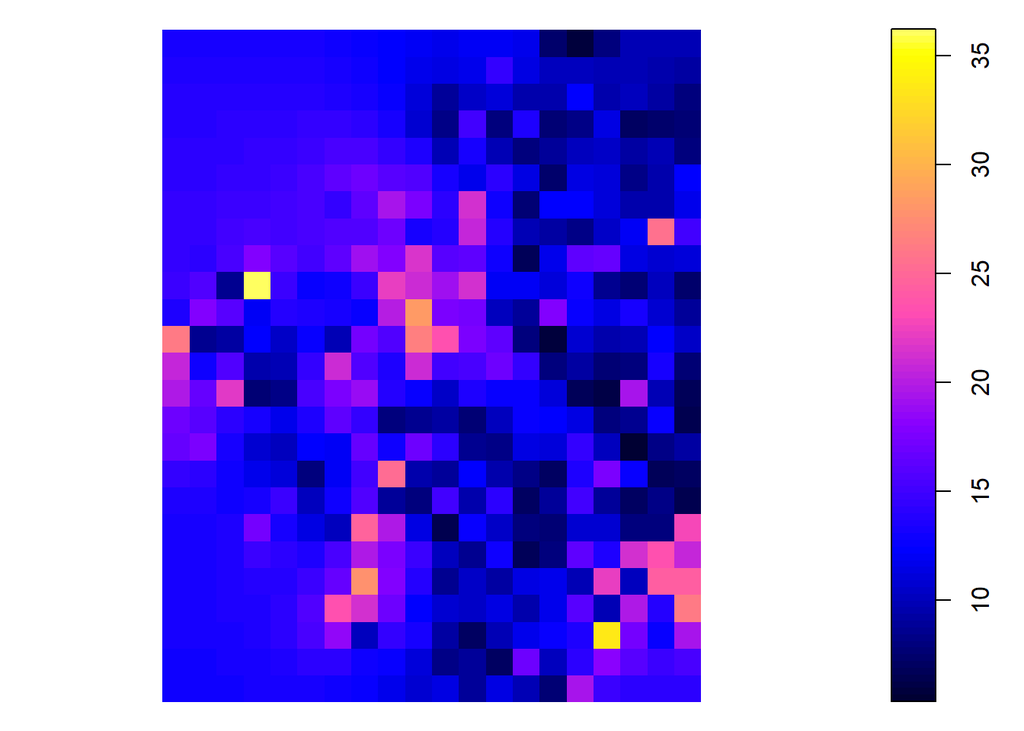

```r
#power values range between 1-3 with a smaller number creating a smoother surface (stronger influence from surrounding points) and a larger number creating a surface that is more true to the actual data and in turn a less smooth surface potentially
plot(P.orig.idw)
```

```r
#then interpolation
grid<-as.data.frame(spsample(acru.spdf ,"regular", n=500))
names(grid)       <- c("X", "Y")
coordinates(grid) <- c("X", "Y")
gridded(grid)     <- TRUE  # Create SpatialPixel object
fullgrid(grid)    <- TRUE  # Create SpatialGrid object
# Add P's projection information to the empty grid
proj4string(grid) <- proj4string(acru.spdf)

# Interpolate the grid cells using a power value of 1 (idp=.0)
#This has the most smoothing
P.idw <- gstat::idw(dbh91 ~ 1, acru.spdf, newdata=grid, idp=1.0)
```

```
## [inverse distance weighted interpolation]
```

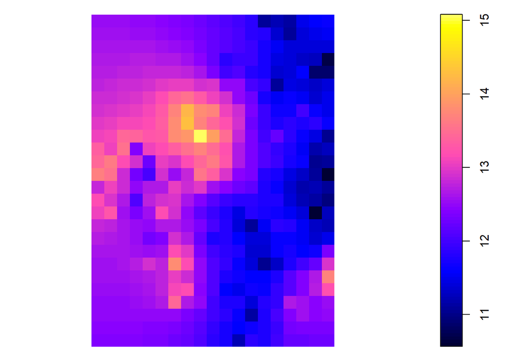

```r
plot(P.idw)
```

The output from these expand our data to cover all the places that we didnt sample. Essintially, they are saying that if there were trees covering the area, these are the expected diameter at breast height values. There are 2 versions. The first is more pixelated and true to the original data. The second is more smooth. This is beacause they have different levels of influence from surrounding points. THe second graph takes more of its influence of values from other points, so the values average out more across space.

# Citations

https://rdrr.io/rforge/spdep/man/localG.html For G star  
https://github.com/r-spatial/spdep/blob/master/man/localG.Rd For localG  
https://cran.r-project.org/web/packages/lctools/vignettes/SpatialAutocorrelation.pdf  
https://mltconsecol.github.io/TU_LandscapeAnalysis_Documents/Assignments_web/Assignment06_Autocorrelation.pdf  
Harvard Trees https://gdmdata.com/media/documents/handouts/2017ASA_FarmToTable_Spatial_correlation.pdf  
https://rstudio-pubs-static.s3.amazonaws.com/223305_944ddc517306448f8fb0d60ca29dd94b.html